# Analysis on pairwise competition assays

Chang-Yu Chang

2019-10-10

# Goal

- Read pairwise competition outcomes that are determined by colony counts on plates.
- Filter out ambiguous pairs and later fill in the data hole by CASEU results
- Map pairs and isolates to the 96-well plate layout
- Determine pairwise interactions

# Read the pairwise competitive outcomes determined by colony counting on TSA

Generate table for manual key-in

Then I manually checked the scanned plate images of competitive pairs. The plate images are saved in folder `plate_scan/high_order_plate_scan/` and divided according the experimental batches.

| Batch | Community |
| --- | --- |
| B2 | 2.6, 2.8, 7.1, 8.4, 10.2, 11.1 |
| C | 11.1 isolate 1 |
| C2 | 11.2 |
| D | 1.2, 1.4, 1.6, 1.7, 4.1, 11.5 |

```
Column `Experiment` joining factor and character vector, coercing into character vector
```

There are 558 pairs of competitive outcomes.

| Experiment | Community | Isolate1 | Isolate2 | Isolate1Freq | Isolate2Freq | ColonyCount | ColonyCount1 | ColonyCount2 | DilutionFactor |
| --- | --- | --- | --- | --- | --- | --- | --- | --- | --- |
| Transitivity_D | C1R2 | 1 | 2 | 5 | 95 | 51 | 51 | 0 | NA |
| Transitivity_D | C1R2 | 1 | 2 | 50 | 50 | 53 | 53 | 0 | NA |
| Transitivity_D | C1R2 | 1 | 2 | 95 | 5 | 84 | 84 | 0 | NA |
| Transitivity_D | C1R2 | 1 | 3 | 5 | 95 | 270 | 0 | 270 | NA |
| Transitivity_D | C1R2 | 1 | 3 | 50 | 50 | 203 | 0 | 203 | NA |
| Transitivity_D | C1R2 | 1 | 3 | 95 | 5 | 117 | 105 | 12 | NA |
| Transitivity_D | C1R2 | 1 | 4 | 5 | 95 | 37 | 37 | 0 | NA |
| Transitivity_D | C1R2 | 1 | 4 | 50 | 50 | 69 | 69 | 0 | NA |
| Transitivity_D | C1R2 | 1 | 4 | 95 | 5 | 105 | 105 | 0 | NA |
| Transitivity_D | C1R2 | 2 | 3 | 5 | 95 | 169 | 0 | 169 | NA |

[output cut: 548 more lines]

186 pairs in total

| Community | Isolate1 | Isolate2 | Count |
| --- | --- | --- | --- |
| C1R2 | 1 | 2 | 3 |
| C1R2 | 1 | 3 | 3 |
| C1R2 | 1 | 4 | 3 |
| C1R2 | 2 | 3 | 3 |
| C1R2 | 2 | 4 | 3 |
| C1R2 | 3 | 4 | 3 |
| C1R4 | 1 | 2 | 3 |
| C1R4 | 1 | 3 | 3 |
| C1R4 | 1 | 4 | 3 |
| C1R4 | 1 | 5 | 3 |

[output cut: 176 more lines]

Write pairwise competition result in `data/temp/pairs_competition.csv` and the pairs basic files in `pairs.csv`

# Ambiguous pairs and isolates on TSA agar plates

There are 67 pair-freqs that I don’t know the competitive outcomes by TSA plate counting. The ambiguous pairs will be later examined by using selective media or Sanger sequencing.

28 distinct pairs

36 isolates that are involved in the ambiguous pairs.

Write the ambiguous pair in `data/temp/pairs_ambiguous.csv` and ambiguous isolates to `data/temp/isolates_ambiguous.csv`

# Map pairs and isolates to the DW96 plate layout

Each plate has 96 rows and has the following variables

Read plate layout by batch

Output pdf `figure/CASEU_pilot2_pairs.pdf` that has the colony morphology ambiguous pairs on DW96 plates layout.

Plate layout that takes different initial frequencies:

- P1 is 50%:50%.
- P2 and P3 are identical and whose rows are 95% and columns are 5%.

The only exception is plate C11R1 in batch C, which only has one plate.

Write the ambiguous pairs location on 96 deep-well plates

# Combine outcomes of pairwise competition from CFU counts and CASEU

The two Rmd reports process raw data (e.g., CFU counts and CASEU sanger sequences) and generate temporary result csv:

1. `02A-CASEU_sanger_seq.Rmd` reads CASEU raw data and outputs `temp/CASEU_pilot2.csv` and `temp/CASEU_pilot3.csv`. Both files are CASEU predicted T8 frequenciex.
2. `02B-pairs_OD_CFU.Rmd` reads pair_competition and dilution factor data, and it outputs `temp/pairs_CFU_freq_uncertainty.csv`, which has the T0 OD-converted CFU frequencies and T8 CFU frequencies with uncertainties.

**Note that if a pair has both CFU and CASEU result, CASEU will overwrite the CFU result**

The script in this section returns a df `pairs_freq` that has the following variables:

- `Community`
- `Isolate1` and `Isolate2`: indices of isolates. The number of isolate1 is always smaller than isolate2
- `Isolate1InitialODFreq` and `Isolate2InitialODFreq`: 5, 50 or 95. The initial OD frequencies of isolates at T0. This two serve as discrete grouping variables.
- `Time`: T0 or T8.
- `Isolate1MeasuredFreq`: the measured frequency od isolate1 in the pair.
- `ErrorIsolate1MeasuredFreq`: the uncertainty of `Isolate1MeasuredFreq`.
- `RawDataType`: OD, ODtoCFU, CFU, Sanger (CASEU). The raw data type in which the isolate frequencies were measured.
- `Contamination`: logical. There are contaminations in three pairs at T8 plates.

There are 26 pair-freq (11 pairwise interactions) that cannot be specified yet.

10 pairs that will be sequenced in CASEU pilot4

# Determine pairwise interactions

Plot frequency changes. Output figure of CFU frequency changes to `output/figure/pairs_freq_change_uncertainty.pdf`

Signs of frequencies changes in pairs

## Coexistence pairs

This section is made for Sylvie’ choose

Pairs that started from 50-50 initial frequency and coexisted at T8

Pairs that coexisted at T8 from three initial frequencies.

# Pairwise phylogenetic distances vs. outcome of pairwise competition

## RDP taxonomy

Fermenter vs. Interaction type

Family vs. Interaction type

## Distribution of pairwise 16S differences

Pairwise 16S differences

16S sequence difference vs. Interaction type

## Pairwise distances of tipe from a

Pairwise tree distance

# Fraction of coexistence links within community

| Community | coexistence | exclusion | FracCoext | CommunitySize |
| --- | --- | --- | --- | --- |
| C1R2 | 2 | 4 | 0.3333333 | 4 |
| C1R4 | 3 | 7 | 0.3000000 | 5 |
| C1R6 | 3 | 7 | 0.3000000 | 5 |
| C1R7 | 4 | 17 | 0.1904762 | 7 |
| C2R6 | 2 | 1 | 0.6666667 | 4 |
| C2R8 | 1 | 3 | 0.2500000 | 4 |
| C4R1 | 1 | 1 | 0.5000000 | 3 |
| C7R1 | 1 | 3 | 0.2500000 | 4 |
| C8R4 | 2 | NA | NA | 3 |
| C10R2 | 1 | 2 | 0.3333333 | 3 |

[output cut: 3 more lines]

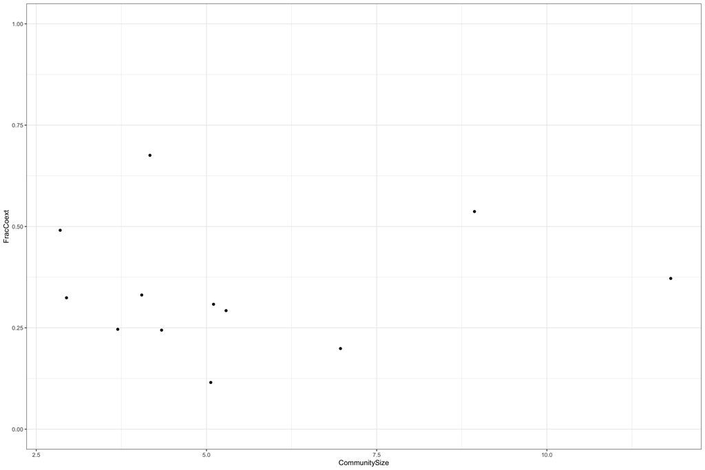

# Fraction frequency histogram